# iPSC human cell lines: all genmes

Joyce Hsiao

2016-01-31

```r
library(qtlcharts)
library(CountClust)
library(parallel)
library(cellcycleR)
library(data.table)
library(binhf)
library(vioplot)
library(limma)
library(readxl)
library(Humanzee)
library(mygene)
library(knitr)
```

## Background and objectives

We fit the sinusoidal model on iPSC scRNA-seq data, one individual at a time. Here we attempt o include all genes in the model.

The data is not yet publicly available, but you can check out [John Blischak’s website](http://jdblischak.github.io/singleCellSeq/analysis/) for the description of experiment protocol, and results of preliminary data analyses.

## Data prepration

### Import final batch-corrected iPSC data

```r
molecules_final <- read.table("../data/gilad-2015/molecules-final.txt",
                              header = TRUE,
                              stringsAsFactors = FALSE)
anno_filter <- read.table("../data/gilad-2015/annotation-filter.txt",
                          header = TRUE,
                          stringsAsFactors = FALSE)
dim(molecules_final)
```

```
## [1] 12192   560
```

```r
table(anno_filter$individual)
```

```
##
## NA19098 NA19101 NA19239
##     141     199     220
```

## NA19239

Extract only data of one individual

```r
molecules_final_19239 <- molecules_final[ , anno_filter$individual == "NA19239"]
dim(molecules_final_19239)
```

```
## [1] 12192   220
```

z-score transformation for each cell

```r
cycle_data_normed_19239 <- apply(molecules_final_19239, 2,
                            function(x)  return (x-mean(x))/sd(x))
cycle_data_normed_19239 <- t(cycle_data_normed_19239)
```

Fitting on all genes

```r
if (file.exists("../rdas/gilad-ipsc-all-genes-2016-01-31/cellorder-19239.rda")) {
    load("../rdas/gilad-ipsc-all-genes-2016-01-31/cellorder-19239.rda")
} else {
results <- sin_cell_ordering_class(cycle_data_normed_19239,
                                   celltime_levels = 300,
                                   num_iter = 300)
save(results,
     file = "../rdas/gilad-ipsc-all-genes-2016-01-31/cellorder-19239.rda" )
}
str(results)
```

```
## List of 6
##  $ cell_times      : num [1:220] 1.13 1.13 1.16 1.16 1.13 ...
##  $ amp             : num [1:12192] 11.28 2.44 4.21 8.09 16.91 ...
##  $ phi             : num [1:12192] 2.21 5.41 2.56 5.15 5.16 ...
##  $ sigma           : num [1:12192] 0.982 1.243 1.049 1.338 1.163 ...
##  $ loglik          : num -3865936
##  $ signal_intensity: num [1:220, 1:300] -207881 -198964 -211353 -215724 -204902 ...
```

Post-processing of cell-phase order.

```r
cell_order_full <- cell_ordering_full(results$signal_intensity,
                                      dim(cycle_data_normed_19239)[2])
str(cell_order_full)
```

```
##  num [1:220(1d)] 1.12 1.14 1.15 1.15 1.11 ...
```

### Model estimates

We look at the plots of the amplitudes, phases and the non signal variation of the genes.

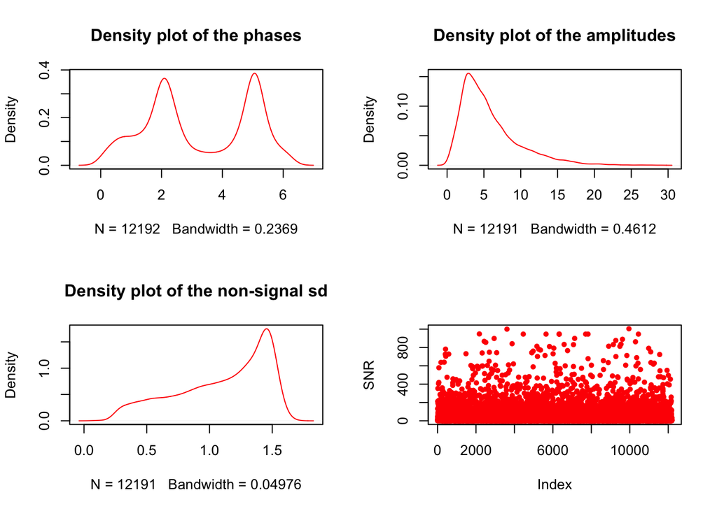

```r
amp_genes <- results$amp
sd_genes <- results$sigma
phi_genes <- results$phi

par(mfrow=c(2,2))
plot(density(phi_genes), col="red",
     main="Density plot of the phases")
plot(density(amp_genes[-which.max(amp_genes)]), col="red",
     main="Density plot of the amplitudes")
plot(density(sd_genes[-which.max(sd_genes)]), col="red",
     main="Density plot of the non-signal sd")

ESS <- amp_genes^2
RSS <- sd_genes^2
SNR <- ESS/RSS
plot(SNR, col="red", pch=20, lwd=1)
```

### Re-ordered expression pattern

We extract the genes with high SNR - these are more likely to be sinusoidal.

```r
sum(SNR > 500)
```

```
## [1] 102
```

```r
top_genes <- which(SNR > 500)

cut <- 500
    top_genes <- which(SNR > cut)
    new_cell_order <- binhf::shift(order(cell_order_full), 130, dir = "right")
    iplotCurves(t(cycle_data_normed_19239[new_cell_order, top_genes]),
                chartOpts = list(title = paste("SNR > ", cut)))
```

```
## Set screen size to height=700 x width=1000
```

[interactive chart not shown]

## Re-fitting on high SNR genes

We extract the high SNR genes as they seem to have sinusoidal patterns and repeat the procedure again.

```r
snr_high_indices <- which(SNR > 500)
cycle_data_normed_high_snr_19239 <- cycle_data_normed_19239[ ,snr_high_indices]
dim(cycle_data_normed_high_snr_19239)
```

```
## [1] 220 102
```

Modeing fitting…

```r
if (file.exists("../rdas/gilad-ipsc-all-genes-2016-01-31/cellorder-19239-high-snr.rda")) {
    load("../rdas/gilad-ipsc-all-genes-2016-01-31/cellorder-19239-high-snr.rda")
} else {
results_high_snr <- sin_cell_ordering_class(cycle_data_normed_high_snr_19239,
                                           celltime_levels = 300, num_iter=200)
save(results_high_snr,
     file = "../rdas/gilad-ipsc-all-genes-2016-01-31/cellorder-19239-high-snr.rda")
}
```

Post-processing

```r
cell_order_full_refit <- cell_ordering_full(results_high_snr$signal_intensity,
                                           dim(cycle_data_normed_high_snr_19239)[2] )
```

### Model estimates

We plot the same features as above and check for the robustness. We needed to shift the cell order so as to compare with previous plot on all genes as the method is non-identifiable upto a rotation.

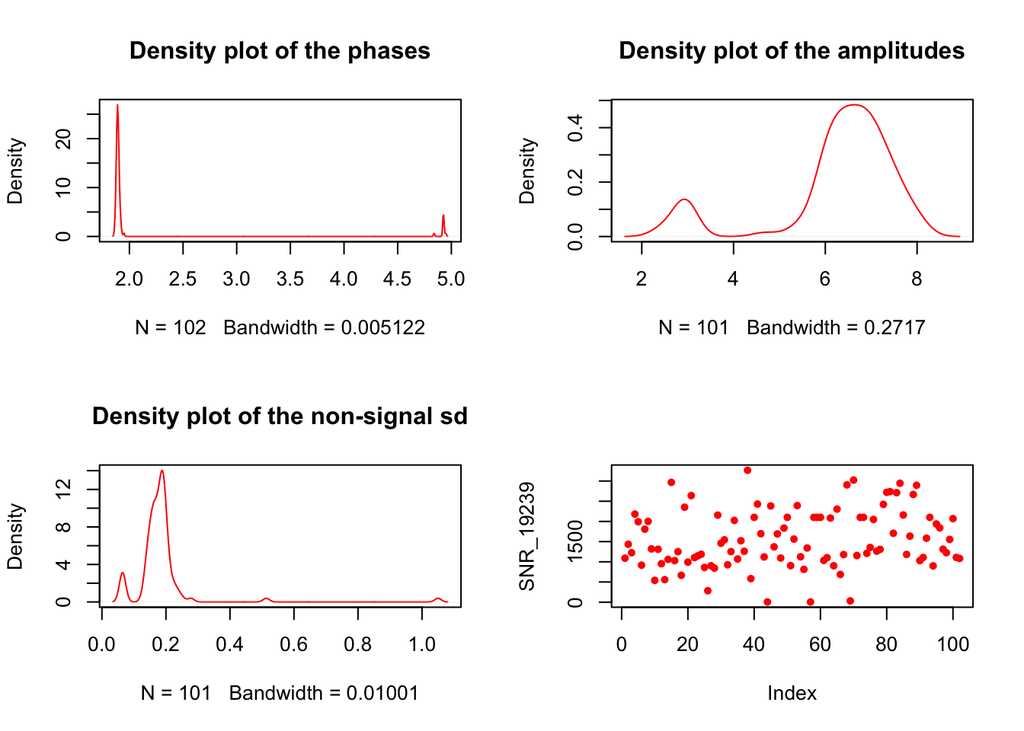

```r
amp_genes <- results_high_snr$amp;
sd_genes <- results_high_snr$sigma;
phi_genes <- results_high_snr$phi;

par(mfrow = c(2,2))
plot(density(phi_genes), col="red", main="Density plot of the phases")
plot(density(amp_genes[-which.max(amp_genes)]), col="red", main="Density plot of the amplitudes")
plot(density(sd_genes[-which.max(sd_genes)]), col="red", main="Density plot of the non-signal sd")

ESS <- amp_genes^2; RSS <- sd_genes^2
SNR_19239 <- ESS/RSS;
plot(SNR_19239, col="red", pch=20, lwd=1)
```

```r
summary(SNR_19239)
```

```
##     Min.  1st Qu.   Median     Mean  3rd Qu.     Max.
##    5.427 1085.000 1349.000 1553.000 2101.000 3267.000
```

### Re-ordered expression patterns

```r
new_cell_order <- binhf::shift(order(cell_order_full_refit), 130, dir = "right")
iplotCurves(t(cycle_data_normed_high_snr_19239[new_cell_order, ]) )
```

[interactive chart not shown]

## Compare fits

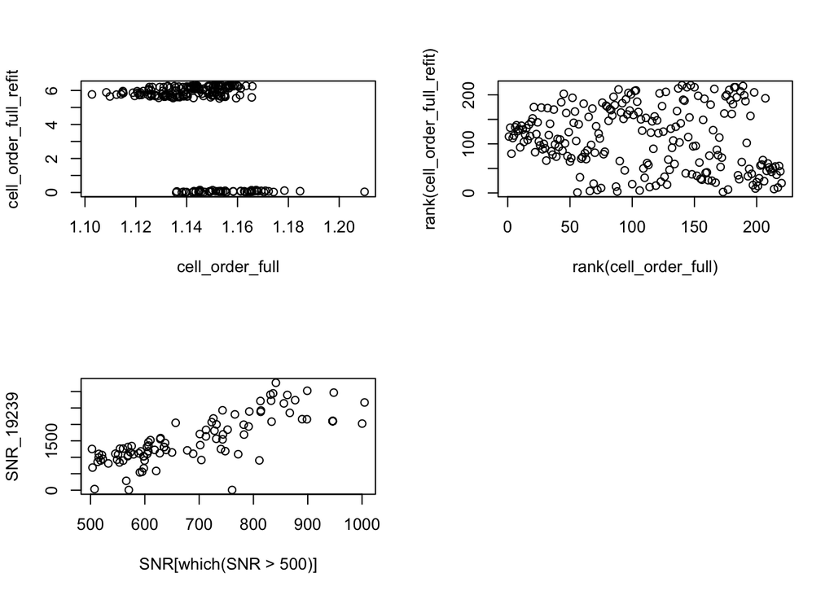

```r
par(mfrow = c(2,2))
plot(x = cell_order_full, y = cell_order_full_refit)
plot(x = rank(cell_order_full), y = rank(cell_order_full_refit))
plot(x = SNR[which(SNR > 500)], y = SNR_19239)
```

## Annotation

```r
query_gene_names <- colnames(cycle_data_normed_high_snr_19239)
query_gene_names_ordered <- query_gene_names[order(SNR_19239, decreasing = TRUE)]

gene_query <- queryMany(query_gene_names_ordered[1:30],
                        scopes="ensembl.gene",
                        fields=c("name","summary"), species="human")
```

```
## Finished
## Pass returnall=TRUE to return lists of duplicate or missing query terms.
```

```r
kable(as.data.frame(gene_query))
```

| summary | name | query | X_id | notfound |
| --- | --- | --- | --- | --- |
| Ribosomes, the organelles that catalyze protein synthesis, consist of a small 40S subunit and a large 60S subunit. Together these subunits are composed of 4 RNA species and approximately 80 structural… | ribosomal protein, large, P1 | ENSG00000137818 | 6176 | NA |
| NA | prothymosin, alpha | ENSG00000187514 | 5757 | NA |
| NA | prothymosin alpha-like | ENSG00000187514 | 728026 | NA |
| Ribosomes, the organelles that catalyze protein synthesis, consist of a small 40S subunit and a large 60S subunit. Together these subunits are composed of 4 RNA species and approximately 80 structural… | ribosomal protein S3 | ENSG00000149273 | 6188 | NA |
| This gene encodes a phosphoprotein which moves between the nucleus and the cytoplasm. The gene product is thought to be involved in several processes including regulation of the ARF/p53 pathway. A num… | nucleophosmin (nucleolar phosphoprotein B23, numatrin) | ENSG00000181163 | 4869 | NA |
| Ribosomes, the organelles that catalyze protein synthesis, consist of a small 40S subunit and a large 60S subunit. Together these subunits are composed of 4 RNA species and approximately 80 structural… | ribosomal protein L37a | ENSG00000197756 | 6168 | NA |
| This gene encodes one of six different actin proteins. Actins are highly conserved proteins that are involved in cell motility, structure, and integrity. This actin is a major constituent of the contr… | actin, beta | ENSG00000075624 | 60 | NA |
| Ribosomes, the organelles that catalyze protein synthesis, consist of a small 40S subunit and a large 60S subunit. Together these subunits are composed of 4 RNA species and approximately 80 structural… | ribosomal protein S23 | ENSG00000186468 | 6228 | NA |
| Ribosomes, the organelles that catalyze protein synthesis, consist of a small 40S subunit and a large 60S subunit. Together these subunits are composed of 4 RNA species and approximately 80 structural… | ribosomal protein L37 | ENSG00000145592 | 6167 | NA |
| Ribosomes, the organelles that catalyze protein synthesis, consist of a small 40S subunit and a large 60S subunit. Together these subunits are composed of 4 RNA species and approximately 80 structural… | ribosomal protein S14 | ENSG00000164587 | 6208 | NA |
| This gene encodes a member of the heat shock protein 90 family; these proteins are involved in signal transduction, protein folding and degradation and morphological evolution. This gene encodes the c… | heat shock protein 90kDa alpha family class B member 1 | ENSG00000096384 | 3326 | NA |
| This gene encodes the B subunit of lactate dehydrogenase enzyme, which catalyzes the interconversion of pyruvate and lactate with concomitant interconversion of NADH and NAD+ in a post-glycolysis proc… | lactate dehydrogenase B | ENSG00000111716 | 3945 | NA |
| Ribosomes, the organelles that catalyze protein synthesis, consist of a small 40S subunit and a large 60S subunit. Together these subunits are composed of 4 RNA species and approximately 80 structural… | ribosomal protein L23 | ENSG00000125691 | 9349 | NA |
| Ribosomes, the organelles that catalyze protein synthesis, consist of a small 40S subunit and a large 60S subunit. Together these subunits are composed of 4 RNA species and approximately 80 structural… | ribosomal protein L34 | ENSG00000109475 | 6164 | NA |
| Ribosomes, the organelles that catalyze protein synthesis, consist of a small 40S subunit and a large 60S subunit. Together these subunits are composed of 4 RNA species and approximately 80 structural… | ribosomal protein S19 | ENSG00000105372 | 6223 | NA |
| Ribosomes, the organelles that catalyze protein synthesis, consist of a small 40S subunit and a large 60S subunit. Together these subunits are composed of 4 RNA species and approximately 80 structural… | ribosomal protein L38 | ENSG00000172809 | 6169 | NA |
| This gene encodes a member of the glyceraldehyde-3-phosphate dehydrogenase protein family. The encoded protein has been identified as a moonlighting protein based on its ability to perform mechanistic… | glyceraldehyde-3-phosphate dehydrogenase | ENSG00000111640 | 2597 | NA |
| Ribosomes, the organelles that catalyze protein synthesis, consist of a small 40S subunit and a large 60S subunit. Together these subunits are composed of 4 RNA species and approximately 80 structural… | ribosomal protein L31 | ENSG00000071082 | 6160 | NA |
| Ribosomes, the organelles that catalyze protein synthesis, consist of a small 40S subunit and a large 60S subunit. Together these subunits are composed of 4 RNA species and approximately 80 structural… | ribosomal protein S8 | ENSG00000142937 | 6202 | NA |
| NA | guanine nucleotide binding protein (G protein), beta polypeptide 2-like 1 | ENSG00000204628 | 10399 | NA |
| Ribosomes, the organelles that catalyze protein synthesis, consist of a small 40S subunit and a large 60S subunit. Together these subunits are composed of 4 RNA species and approximately 80 structural… | ribosomal protein, large, P0 | ENSG00000089157 | 6175 | NA |
| This gene encodes a membrane-bound glycoprotein from the family of dipeptidases involved in hydrolytic metabolism of various dipeptides, including penem and carbapenem beta-lactam antibiotics. This ge… | dipeptidase 3 | ENSG00000141096 | 64180 | NA |
| NA | zinc finger protein 560 | ENSG00000198028 | 147741 | NA |
| NA | zinc finger protein 582 | ENSG00000018869 | 147948 | NA |
| NA | zinc finger protein 667 | ENSG00000198046 | 63934 | NA |
| NA | ZFP28 zinc finger protein | ENSG00000196867 | 140612 | NA |
| NA | NA | ENSG00000184674 | NA | TRUE |
| This gene encodes a member of the apolipoprotein B mRNA-editing enzyme catalytic polypeptide 3 family of proteins. The encoded protein is a cytidine deaminase that has antiretroviral activity by gener… | apolipoprotein B mRNA editing enzyme catalytic polypeptide like 3H | ENSG00000100298 | 164668 | NA |
| NA | coiled-coil-helix-coiled-coil-helix domain containing 2 | ENSG00000106153 | 51142 | NA |
| Ubiquitin, a highly conserved protein that has a major role in targeting cellular proteins for degradation by the 26S proteosome, is synthesized as a precursor protein consisting of either polyubiquit… | ribosomal protein S27a | ENSG00000143947 | 6233 | NA |
| Ribosomes, the organelles that catalyze protein synthesis, consist of a small 40S subunit and a large 60S subunit. Together these subunits are composed of 4 RNA species and approximately 80 structural… | ribosomal protein L35 | ENSG00000136942 | 11224 | NA |

## Compare with fitting when using cell-cycle genes only

Load results from fitting only on cell-cycle genes.

```r
load("../rdas/yoav_cycleR_cellcycle_genes-2016-01-28/cellorder-ipsc-2016-01-28.rda")
cell_order_full_cell_cycle <- cell_ordering_full(results$signal_intensity,
                                                 length(results$cell_times) )
```

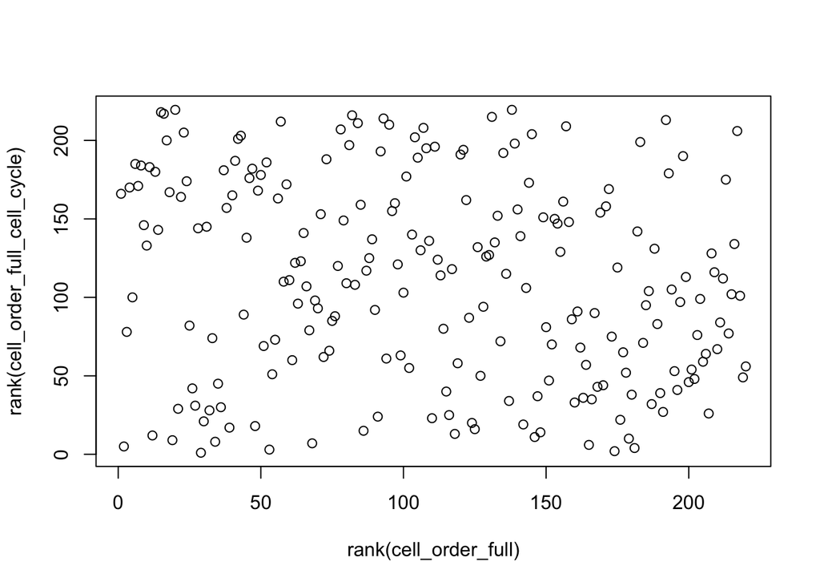

```r
plot(x = rank(cell_order_full), y = rank(cell_order_full_cell_cycle))
```

```r
head(cbind(cell_order_full, cell_order_full_cell_cycle))
```

```
##      cell_order_full cell_order_full_cell_cycle
## [1,]        1.122941                  5.6253593
## [2,]        1.142688                  2.7317260
## [3,]        1.150154                  4.4133450
## [4,]        1.152278                  0.2262604
## [5,]        1.114218                  2.9723922
## [6,]        1.143819                  1.5864107
```